# [PD1] Zaawansowany R

Szymon Maksymiuk

17.10.2019

# 1 Wstęp

W tym krótkim, acz związyłm raporcie pochylę się nad trzema pakietami służącymi generowaniu grafiki w R. Święcącym tryumfy **ggplot2**, nieco już starszym jego kolegą, **lattice** (pierwsza wersja na CRAN w roku 2001), oraz dostarczanym nam wraz z **base** pakietem **graphics**. Spróbuję za pomocą biblioteki **microbenchamrk** porównać czasy działnia pięciu przykładowych wykresów generowanych za pomocą tych trzech bilbiotek. W pracy postaram się użyć raczej prostych wykresów z bardzo praktycznej przyczyny. Chciałbym by porównania miały jak najlepsze odniesienie do codziennych czynności z użyciem grafiki, z którymi przeciętny użytkownik R spotyka się każdego dnia. Za zabiór danych posłuży nam [całkowicie losowy](https://www.openml.org/d/1362) zbiór danych z OpenML, którego jedyną przydatną dla nas cechą jest fakt, że posiada 1000000 (słownie: milion) obserwacji.

```r
library("lattice")
library("ggplot2")
library("graphics") #ot taki żarcik
data <- OpenML::getOMLDataSet(1362L)$data
cat("Size of data:", object.size(data))
```

```
## Size of data: 244023272
```

Oczywiście gołym okiem widać (wszak każdy użytkownik R jest ekspertem informatyki), że nasz zbiór waży 232.72 megabajta, jest więc całkiem duży. Przejdźmy więc do tworzenia grafik.

# 2 Wykresy od nazwiska znanych matematyków, Boxa i Whiskera

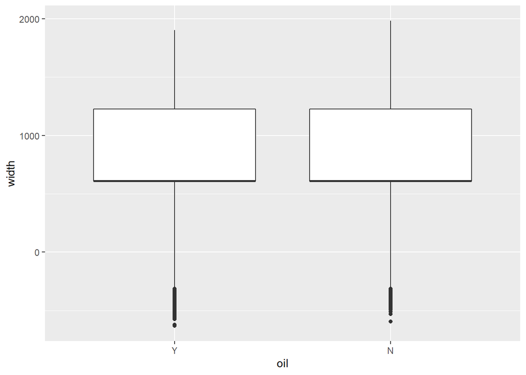

```r
ggplot(data = data, aes(y = width, x = oil)) +
  geom_boxplot()
```

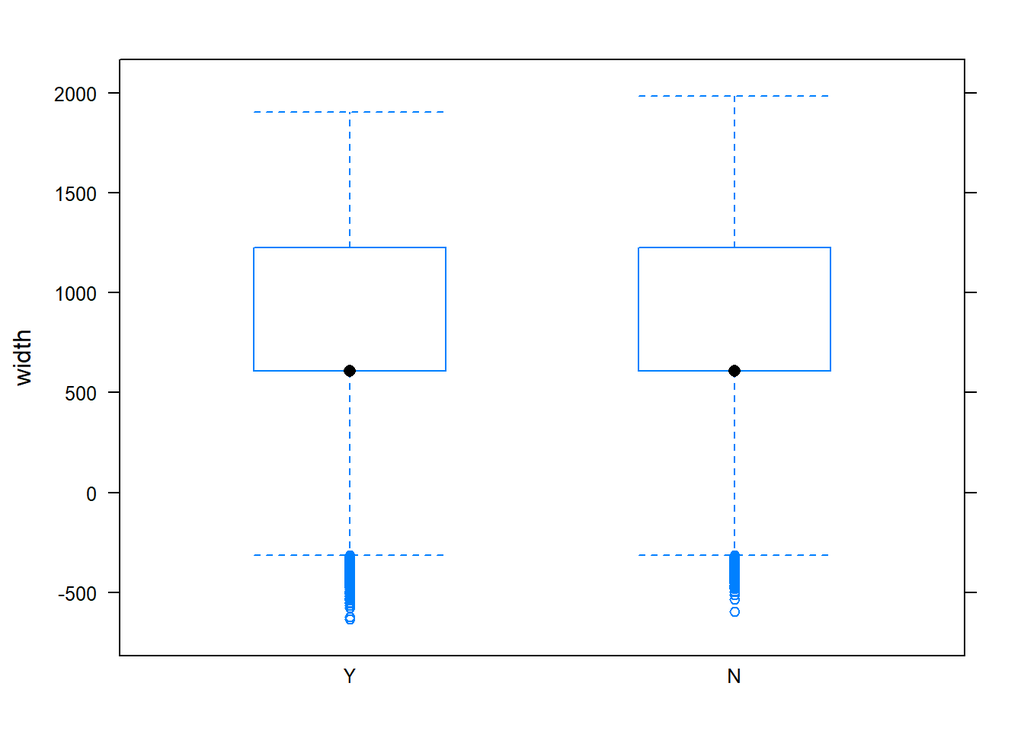

```r
bwplot(width~oil, data = data)
```

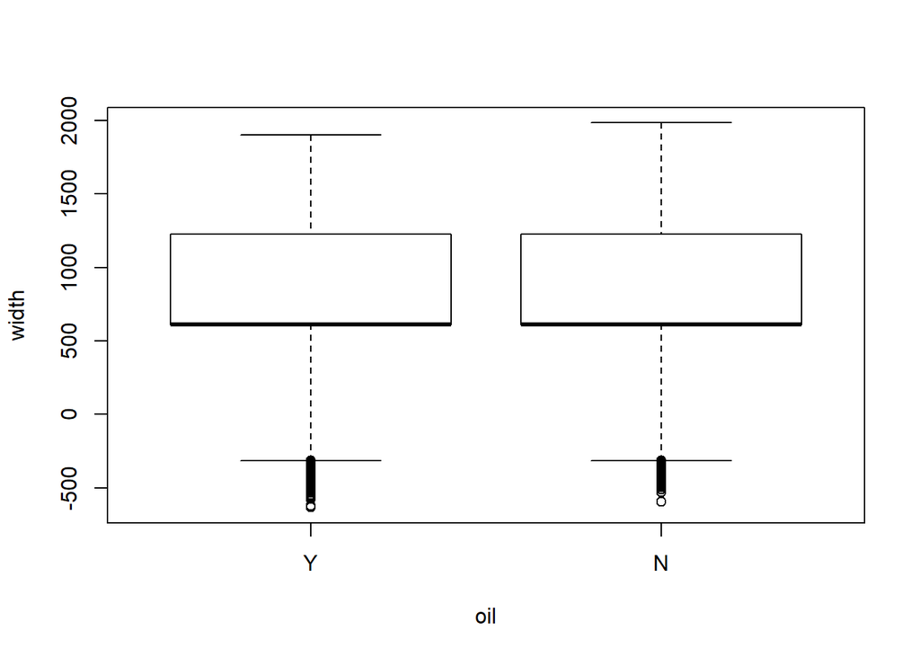

```r
boxplot(width~oil, data = data)
```

# 3 Osobiście mój ulubiony typ a więc gęstość

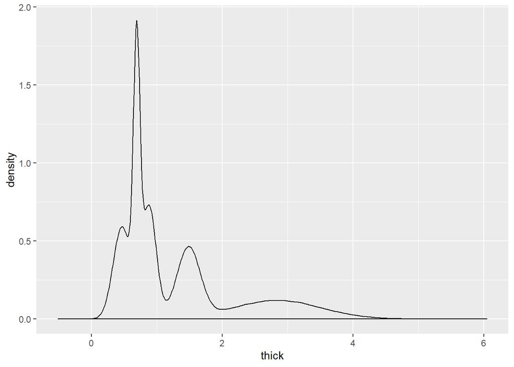

```r
ggplot(data = data, aes(x = thick)) +
  geom_density()
```

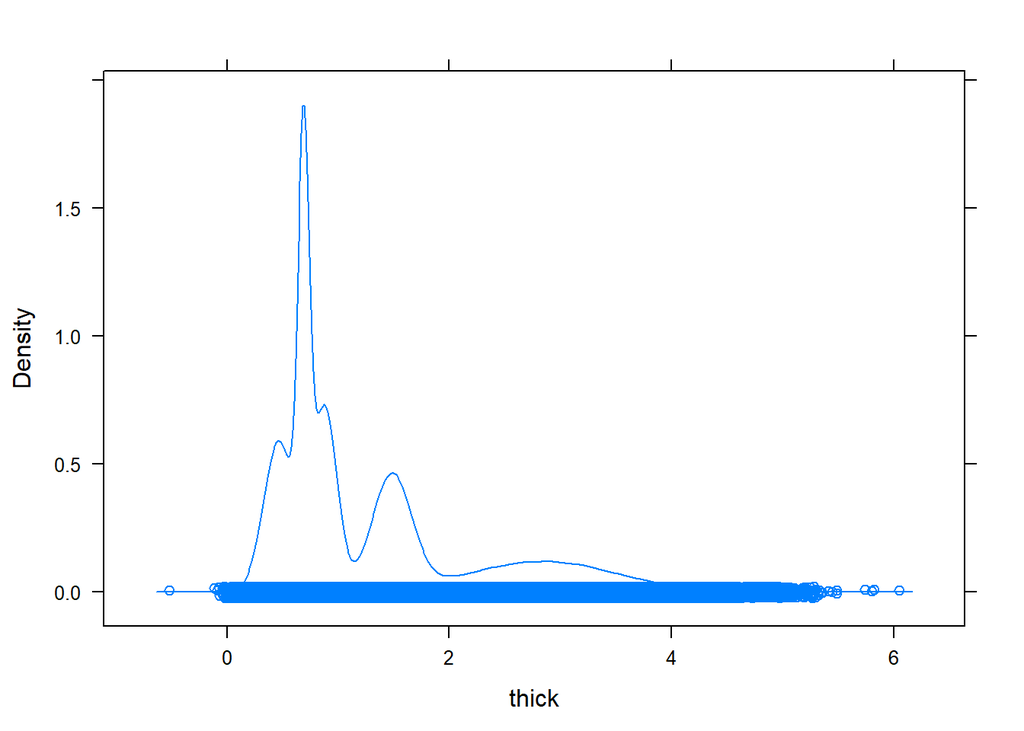

```r
densityplot(~thick, data = data)
```

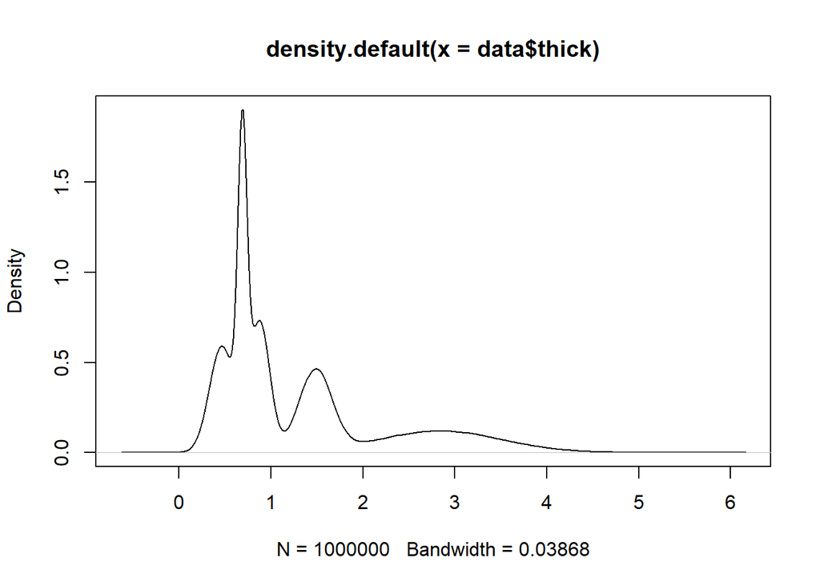

```r
plot(density(data$thick))
```

# 4 Najbardziej lubiany przez media

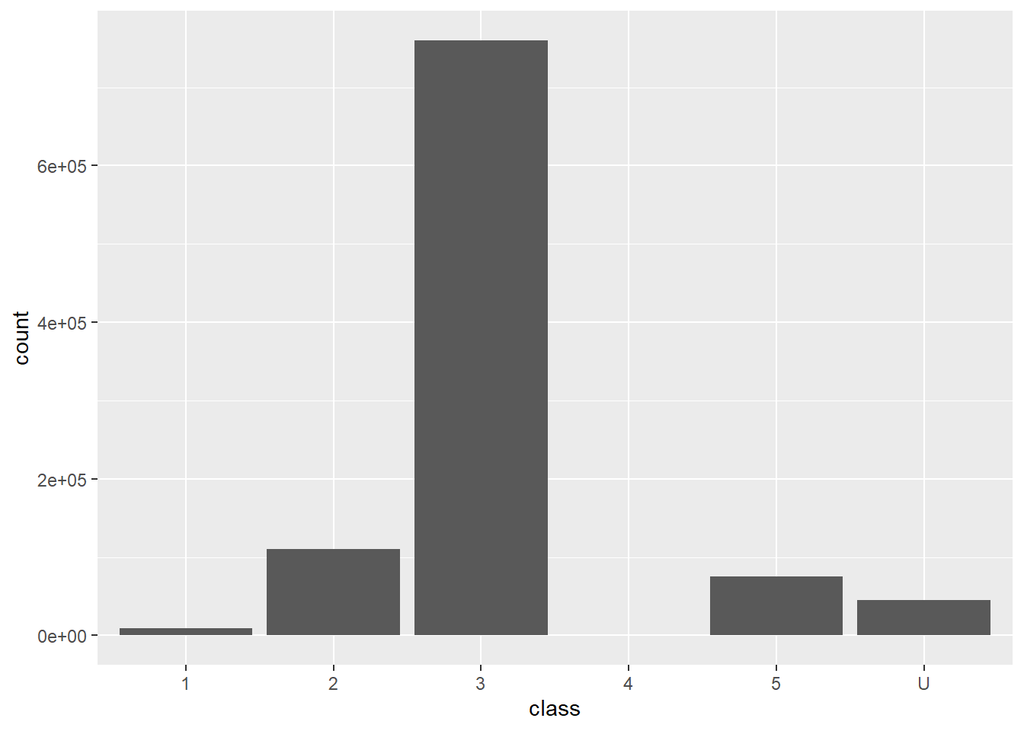

```r
ggplot(data = data, aes(x = class)) +
  geom_bar()
```

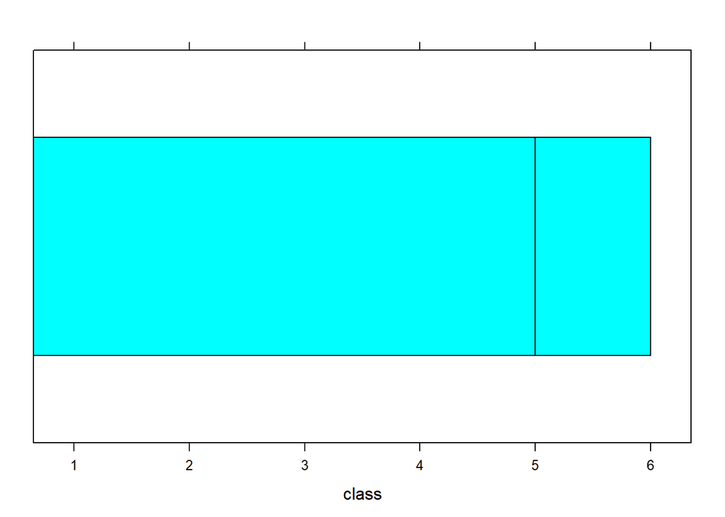

```r
barchart(~class, data = data)
```

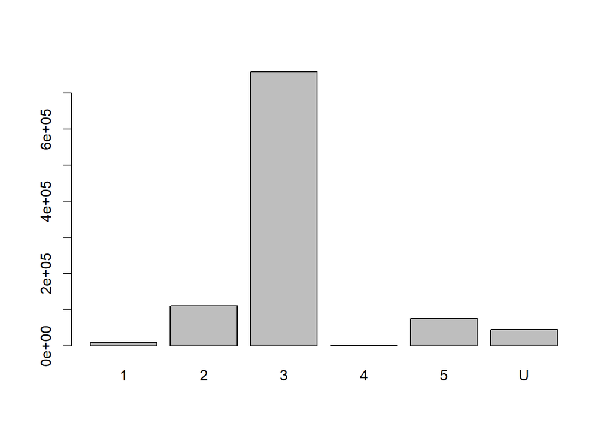

```r
barplot(table(data$class))
```

# 5 Trywiał i banał w środku by nikt nie widział, czyli scatter plot

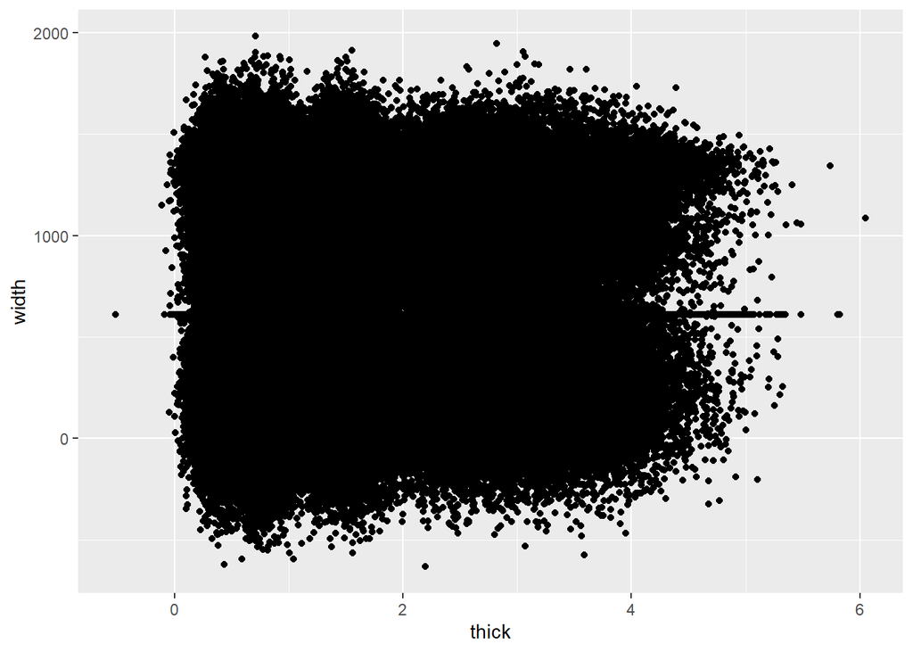

```r
ggplot(data = data, aes(x = thick, y = width))+
  geom_point()
```

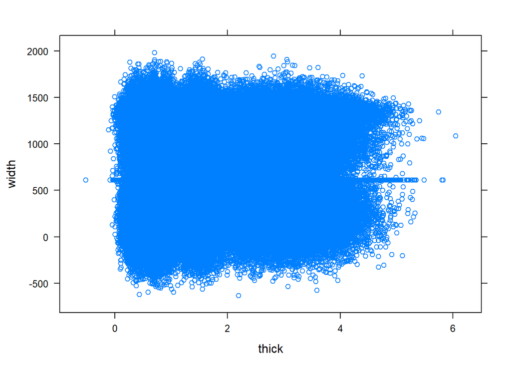

```r
xyplot(width~thick, data = data)
```

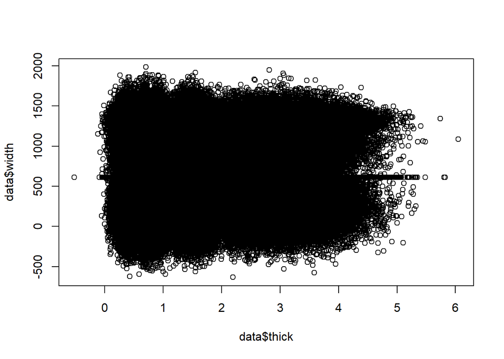

```r
plot(data$thick, data$width)
```

# 6 Zakończmy ładnie czyli histogram

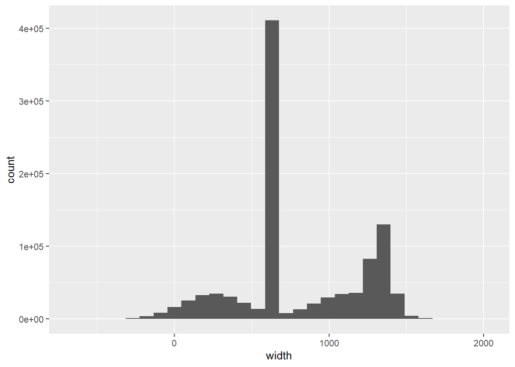

```r
ggplot(data = data, aes(x = width))+
  geom_histogram()
```

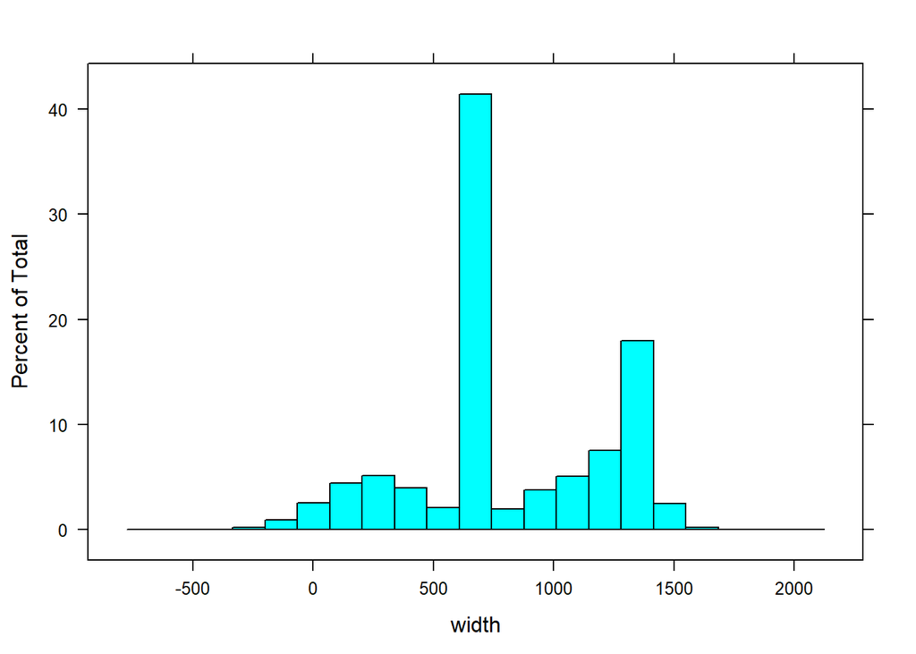

```r
histogram(~width, data = data)
```

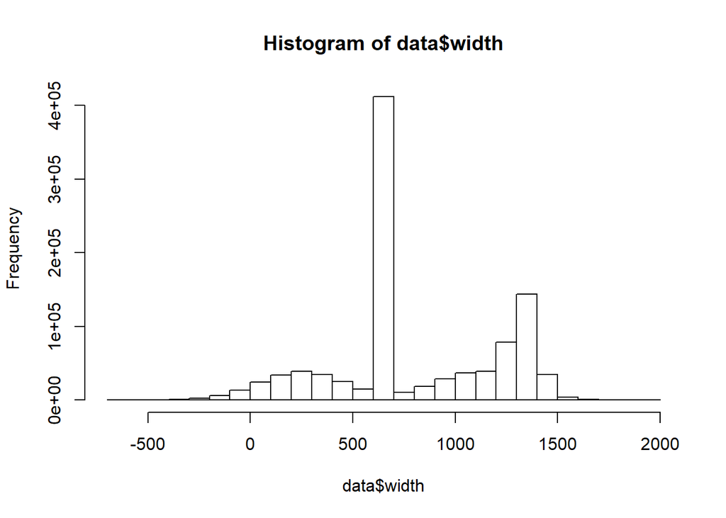

```r
hist(data$width)
```

# 7 Benchmarki

## 7.1 Boxplot

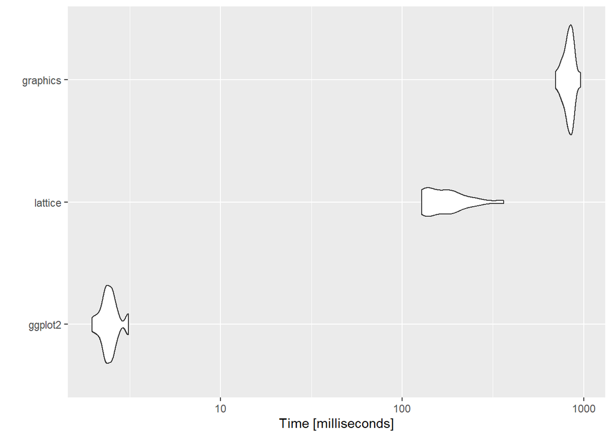

```r
autoplot(bp)
```

## 7.2 Density

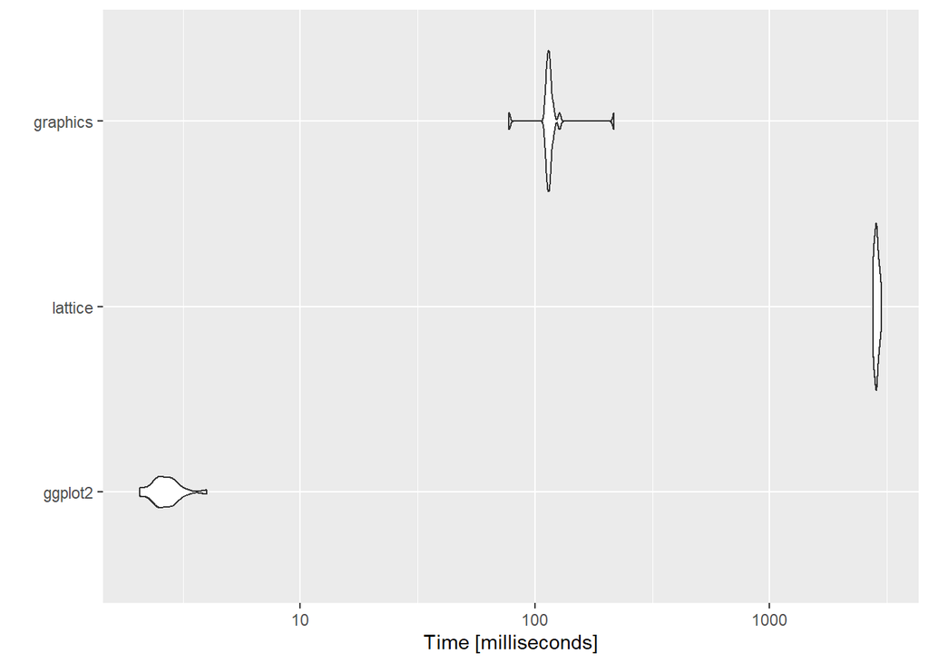

```r
autoplot(dens)
```

## 7.3 Barplot

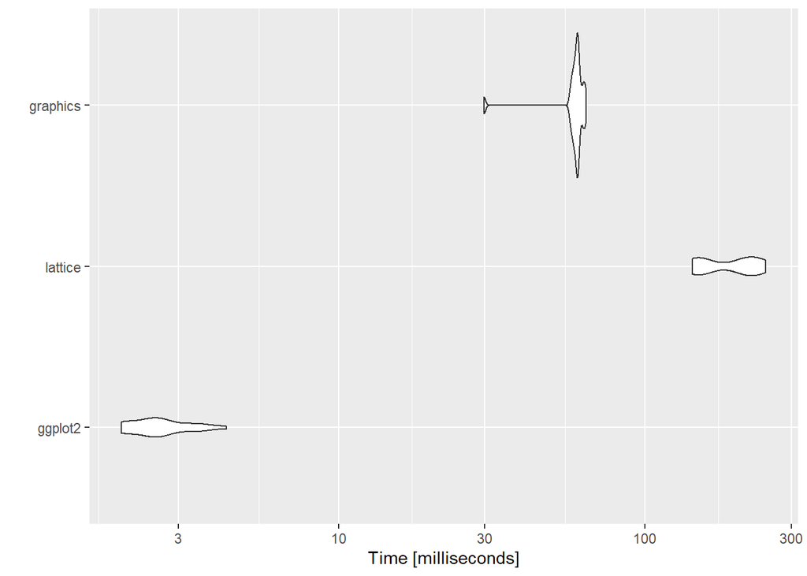

```r
autoplot(col)
```

## 7.4 Scatter

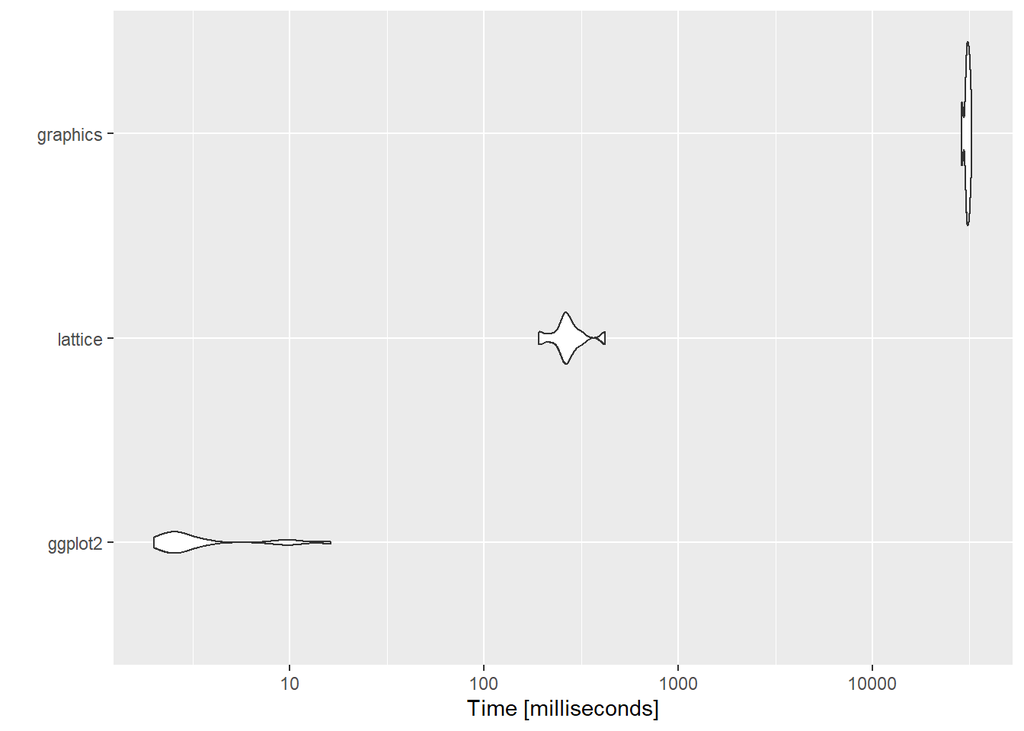

```r
autoplot(sca)
```

## 7.5 Histogram

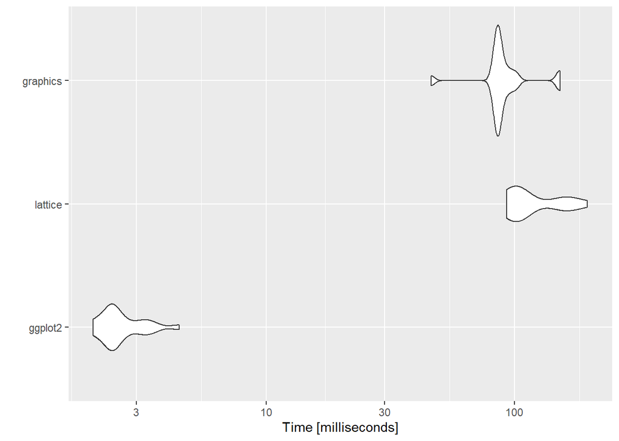

```r
autoplot(hi)
```

# 8 Podsumowanie